# From Reads to Structure

RNA Sequencing, PCA, and K-means Clustering

Philip Leftwich

University of East Anglia

2026-05-13

## A question about the medfly

*Ceratitis capitata* — the Mediterranean fruit fly — is one of the world’s most destructive agricultural pests.

We have measured gene expression in **seven distinct tissues** from adult flies, across mated and virgin individuals.

> **23,268 genes. 33 samples. How do you find structure in that?**

This session covers the tools that make the question answerable: **RNA sequencing**, **PCA**, and **k-means clustering**.

# What is RNA Sequencing?

## Gene activity leaves a molecular trace

Gene expression — which genes are switched on and at what level — defines what a cell is and what it does.

### The central dogma

DNA → **mRNA** → Protein

Measuring mRNA abundance tells us which genes are active in a tissue at a given moment. It is the most direct large-scale readout of gene activity currently available.

### Why sequence?

- A neuron and a liver cell carry identical DNA but express completely different genes
- Mating, stress, and disease all change which genes are active
- You cannot know in advance which genes matter — so you measure all of them

RNA sequencing (RNAseq) does exactly this: it counts the mRNA molecules from every gene in a sample simultaneously.

## From tissue to reads

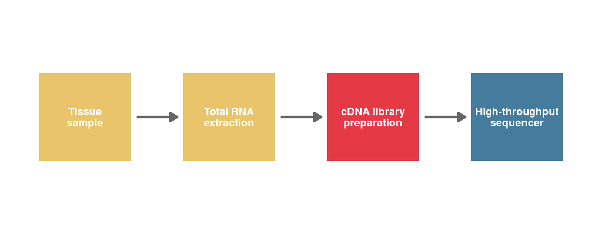

- mRNA is chemically unstable — it is first converted to stable **cDNA** by reverse transcription
- cDNA molecules are fragmented and tagged with sequencing adapters to form a **library**
- The sequencer reads millions of short **sequence reads** (~150 bp each) from the library

## From reads to the count matrix

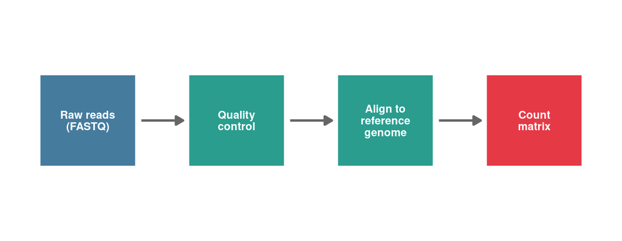

- Reads are checked for quality and adapters are trimmed
- Reads are **aligned** to a reference genome — each read is matched to the gene it came from
- The number of reads mapping to each gene in each sample is counted
- The result is a **count matrix**: rows are genes, columns are samples, values are read counts (or TPM after normalisation)

## The count matrix — our starting point

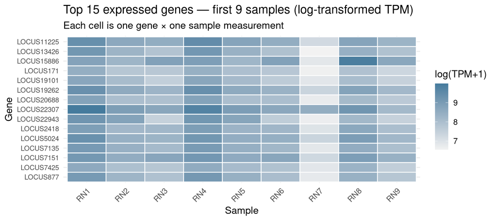

This experiment: **23,268 genes × 33 samples**. The question is what structure these numbers contain.

Many genes are strongly correlated with one another — they rise and fall together across samples. This shared variation is the signal PCA is designed to extract.

# The Dimensionality Problem

## 23,268 genes: too many to plot

To compare every gene against every other gene across 33 samples you would need:

Even restricting to pairwise **sample** comparisons:

$$\binom{33}{2} = 528 \text{ plots}$$

Most would show noise, not biology.

High-dimensional data is the norm in modern biology — not the exception.

## Genes do not vary independently

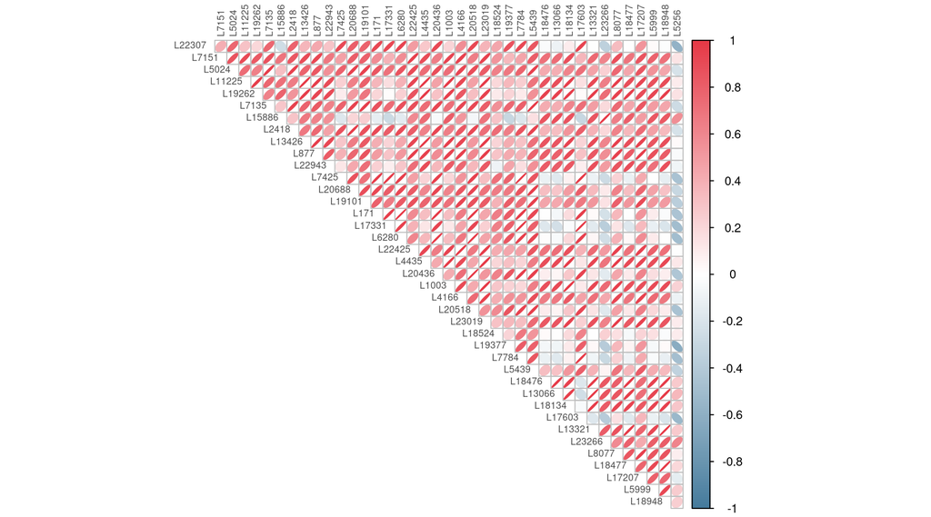

## High dimensionality is everywhere in biology

- **Genomics (GWAS)** — millions of SNPs per individual; which variants associate with disease?
- **Metabolomics** — ~1,000 plasma metabolites; which shift with illness or treatment?
- **Ecology** — species × site abundance matrices; what drives community composition?
- **Single-cell RNAseq** — thousands of genes in thousands of individual cells simultaneously
- **Imaging** — millions of pixels per image; what features distinguish disease states?

In every case, the question is the same: **where is the signal among all this noise, and what does the structure mean biologically?**

# ✋ Stop and Think

## What sources of variation do you expect?

We have gene expression data from **seven tissues** in adult medflies: ovary (young and old), abdomen, testis, accessory gland, and eggs.

In pairs, discuss:

1. Which biological factor do you predict will most strongly separate samples — **tissue type**, **sex**, or **mating status**? Rank your predictions.
2. Would you expect the ovary and testis to have more similar or more different expression profiles than, say, two ovary samples from different individuals?
3. Write your prediction down — you will test it against the PCA shortly.

# Principal Component Analysis

## Variance is information

A gene with identical expression across all samples tells you nothing about what makes samples different from one another.

### No variation → no information

If every sample had the same value for a gene, that gene cannot explain any difference between samples.

### High variation → high information

A gene whose expression differs strongly between tissues is doing something biologically important — or at least something detectable.

**PCA finds the linear combinations of genes that capture maximum variance** — the axes along which samples differ most.

*(Saccenti, 2024)*

## PCA rotates the coordinate system

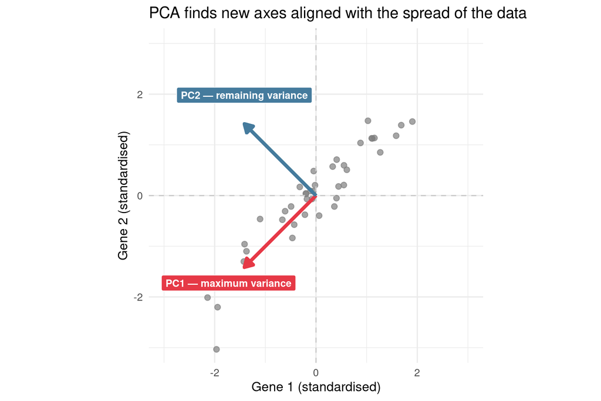

PC1 and PC2 are **orthogonal** — they capture independent axes of variation.

## Three outputs from every PCA

### What you get

1. **Variance explained** — how much of the total variation does each PC capture?
2. **Loadings** — which genes drive each PC?
3. **Scores** — where does each sample sit in PC space?

### Key properties of PCA

- PCs are **ordered** by variance explained
- PCs are **orthogonal** (uncorrelated with each other)
- The analysis is **unsupervised** — no tissue labels are used
- Typically only the first two or three PCs are interpreted

## Variance explained by each PC

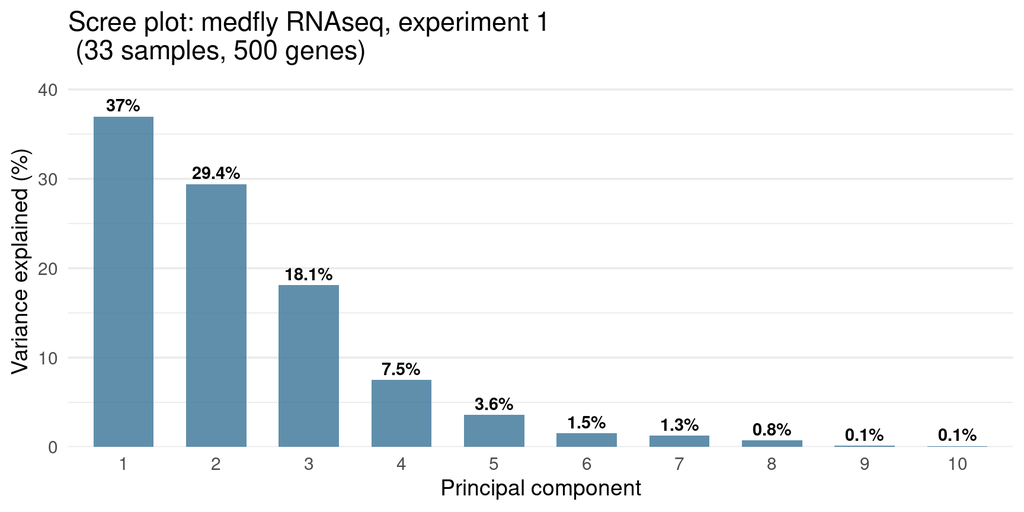

## Which genes drive PC1?

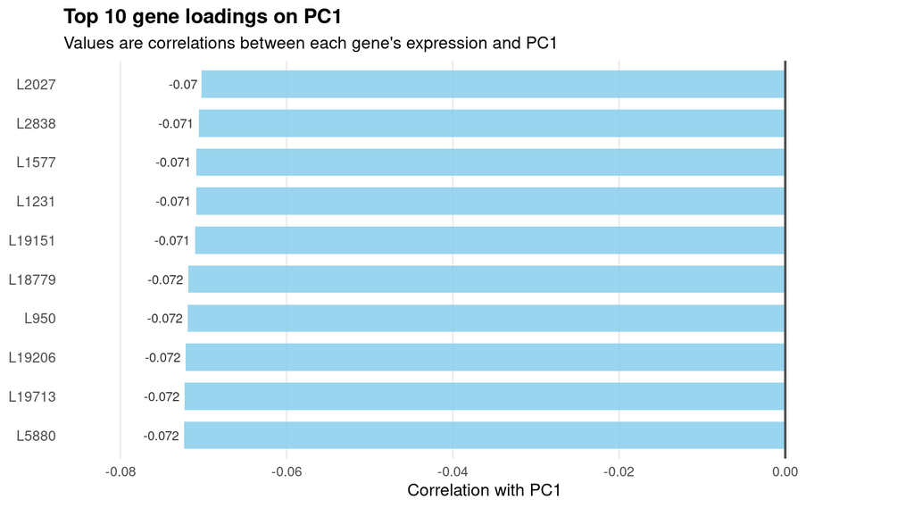

# ✋ Stop and Think

## Where are the samples — and why?

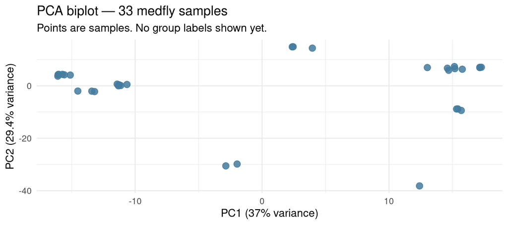

What biological factor do you think separates the clusters? Revisit your prediction from the first stop.

## The reveal — tissue type dominates

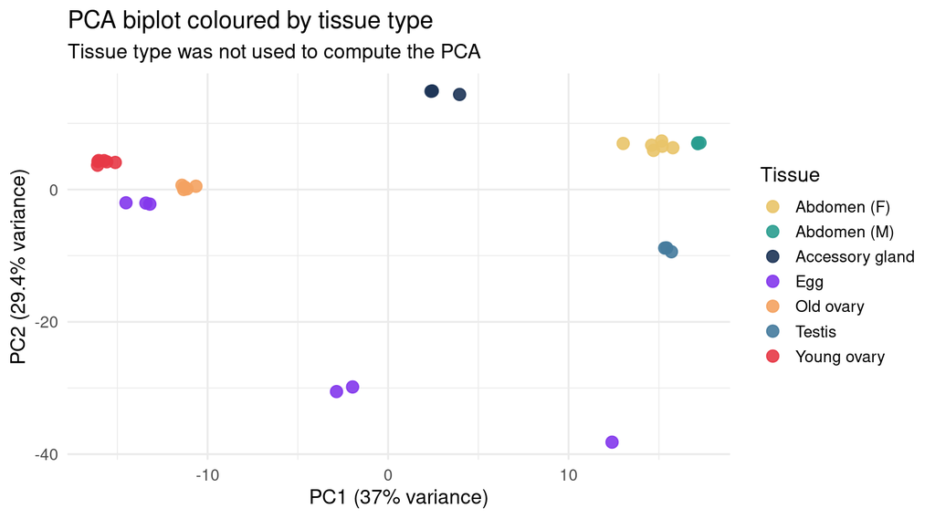

The dominant axis of transcriptomic variation is **tissue identity**, not replicate effects.

## What PCA cannot tell you

### What it reveals

- Which samples are transcriptomically similar
- Which genes drive the main axes of variation
- Whether biological groupings exist in the data

### What it does not reveal

- **Why** tissues cluster together
- Whether differences are **statistically significant**
- Whether the structure would **generalise** to new samples

PCA is a descriptive technique. It reveals correlation structure without establishing cause, and requires no train–test split because no prediction claim is being made.

# K-means Clustering

## From continuous positions to discrete groups

The biplot shows seven tissue clusters but we assigned those labels ourselves. K-means asks: **could we have recovered those groups from the data alone?**

- K-means assigns each sample to one of $k$ clusters by minimising total within-cluster variance
- Run on the **PC scores** rather than the raw 23,268 genes — the PCA has already removed noise
- Every sample belongs to **exactly one** cluster — hard assignment
- The number of clusters $k$ must be specified in advance

## K-means clusters vs tissue labels

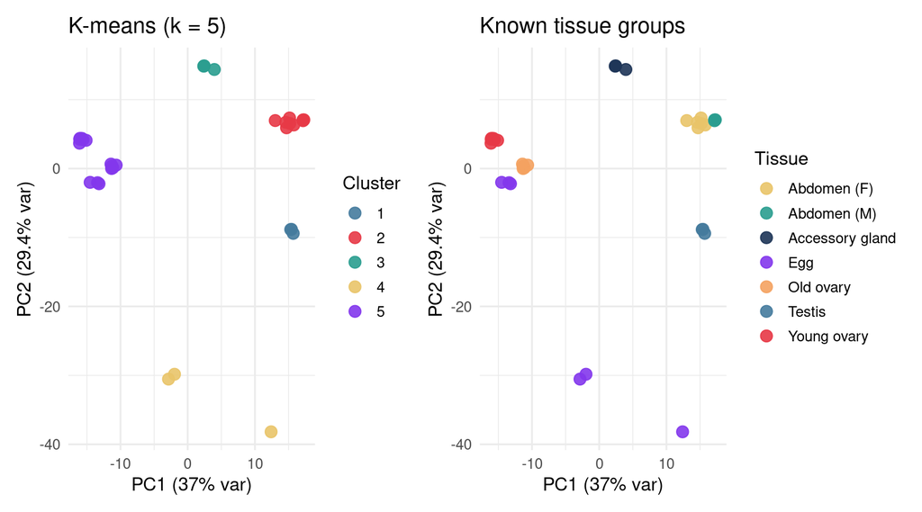

At $k = 5$, k-means partially recovers the tissue structure without having access to the tissue labels.

## How K-means works

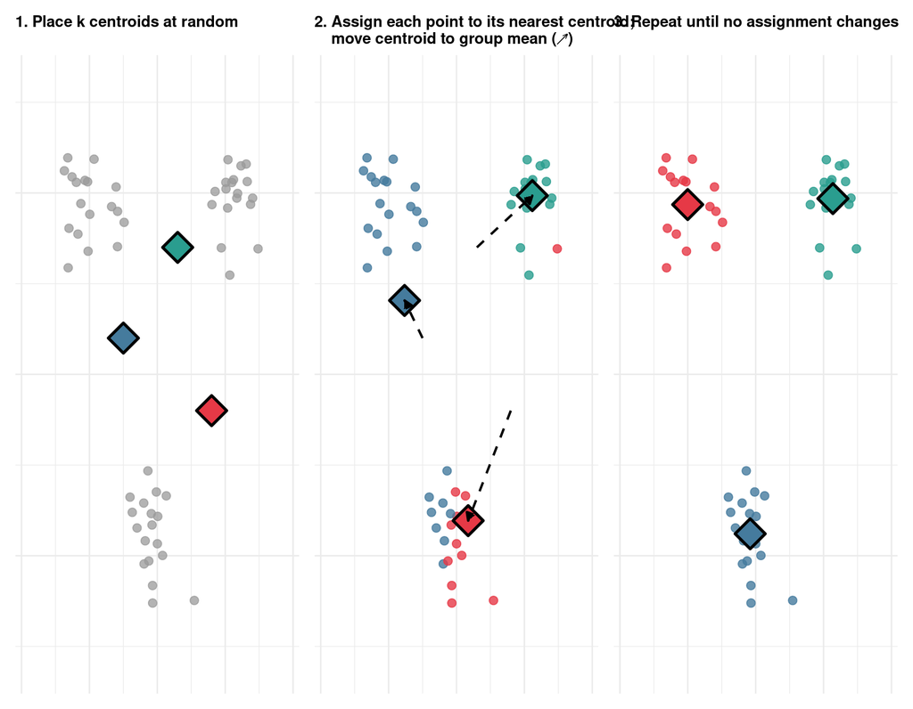

## What k-means minimises

At convergence, k-means has found the assignments that minimise the total within-cluster sum of squares:
$$WSS=∑(distance~from~point~to~centroid)^2$$
This is the same objective as OLS regression, which minimises:

$$RSS=∑(distance~from~point~to~fitted~value)^2$$
:::{.incremental}

- In OLS, each observation is compared to its fitted value — the closest point on the regression line
- In k-means, each observation is compared to its cluster centroid — the closest reference point in PC space
- Both methods find the assignment that minimises total squared distance; only the geometry differs

## Key takeaways

- **RNAseq** converts mRNA abundance into a count matrix: genes × samples
- The count matrix is high-dimensional — direct inspection is impossible
- **PCA** rotates the variable space to find axes of maximum variance; tissue identity dominates PC1 in this medfly dataset
- Loadings identify which genes drive each PC; scores show where each sample sits
- **K-means** partitions PC space into discrete clusters; at $k = 5$ it partially recovers the known tissue groupings

Structure discovered without labels — confirmed with labels. This is how unsupervised analysis should work.

# Backup Slides

## Why log-transform TPM values? (Backup 1)

Although TPM normalises for sequencing depth, the distribution of TPM values remains highly skewed: a small number of genes are expressed at thousands of TPM while most genes sit below 10.

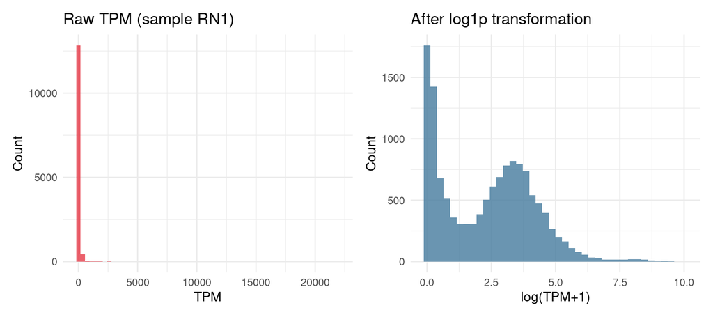

Log transformation compresses the upper tail and stabilises variance — genes across the full expression range then contribute more equally to the PCA.

## Why standardise genes before PCA? (Backup 2)

Even after log transformation, genes differ in their variance across samples. Without standardisation, the genes with the largest absolute variance dominate PC1 regardless of biological importance.

`step_normalize()` transforms each gene to zero mean and unit variance across samples before the eigendecomposition. This ensures that all 500 retained genes contribute to the PCA on equal footing.

For community ecology data where all species are measured in the same units, standardisation is sometimes omitted. For transcriptomics data, it is always applied.

## K-means limitations in transcriptomics (Backup 3)

- **K-means assumes spherical clusters** — elongated or nested structures (e.g., developmental time courses) are partitioned poorly. Hierarchical clustering or UMAP may be more informative for continuous trajectories.
- **The elbow is often ambiguous** in real transcriptomic data. Consider the silhouette width or gap statistic as supplements.
- **Local minima** — always use `nstart = 25` or higher. The optimal solution from multiple random starts is more stable than any single run.
- **K-means on PC scores excludes information** in lower-order PCs. If biologically relevant structure is captured by PC4 or PC5, running k-means on only the first three PCs will miss it.
- **Cluster labels are arbitrary** — the numbering changes between runs without `set.seed()`. Always set a seed before any `kmeans()` call in a reproducible document.